# 7 Covariates

In this session, we will explore how we can identify covariates for our MI patients!

## 7.1 Make a script

First, make a script where we can save our code. Choose either R Markdown/Quarto or R Script.

Name it “covariates”.

Save it in the folder “R”.

## 7.2 Load packages

Load the packages we will need under a section called “Load packages”.

```r
library(tidyverse)
```

## 7.3 Load the datasets

Load the datasets we will need under a section called “Load data”

```r
basic_data <- readRDS(here::here("data-raw/basic_data.rds"))

diag_data <- readRDS(here::here("data-raw/diag_data.rds"))

data_pop_mi <- readRDS(here::here("data/data_pop_mi.rds"))
```

## 7.4 Choose covariates

First, we must decide which covariates we would like to include.

From `basic_data`:

- age
- sex

From `diag_data`:

- Hypertension
- Hypercholesterolaemia
- Diabetes
- Heart failure

## 7.5 Age and sex

In the `basic_data`, we can obtain information on age and sex from the variables `birth_date` and `sex`.

```r
data_cov_01 <- data_pop_mi |>
  left_join(basic_data |> select(id, birth_date, sex),
            by = "id")

data_cov_01
```

```
# A tibble: 4,000 × 5
   id    index_date   los birth_date sex
   <fct> <date>     <dbl> <date>     <fct>
 1 212   2014-07-18     4 1941-01-01 1
 2 483   2017-12-10     9 1918-01-01 2
 3 731   2023-07-27     7 1931-01-01 2
 4 949   2021-11-03     7 1954-01-01 1
 5 981   2020-08-05    13 1945-01-01 2
 6 982   2015-05-22     6 1945-01-01 2
 7 1123  2015-07-25     6 1955-01-01 1
 8 2166  2016-09-30     7 1962-01-01 1
 9 2469  2023-08-26     5 1920-01-02 2
10 2870  2010-09-03    14 1939-01-01 1
# ℹ 3,990 more rows
```

Now, we can calculate age at admission

```r
data_cov_02 <- data_cov_01 |>
  mutate(
    age = floor(as.numeric(difftime(index_date,birth_date, units = "days"))/365.25)
  )

data_cov_02
```

```
# A tibble: 4,000 × 6
   id    index_date   los birth_date sex     age
   <fct> <date>     <dbl> <date>     <fct> <dbl>
 1 212   2014-07-18     4 1941-01-01 1        73
 2 483   2017-12-10     9 1918-01-01 2        99
 3 731   2023-07-27     7 1931-01-01 2        92
 4 949   2021-11-03     7 1954-01-01 1        67
 5 981   2020-08-05    13 1945-01-01 2        75
 6 982   2015-05-22     6 1945-01-01 2        70
 7 1123  2015-07-25     6 1955-01-01 1        60
 8 2166  2016-09-30     7 1962-01-01 1        54
 9 2469  2023-08-26     5 1920-01-02 2       103
10 2870  2010-09-03    14 1939-01-01 1        71
# ℹ 3,990 more rows
```

**Note**

**Explanation**

- `floor()`: rounds exact age down
- `as.numeric()`: specifies that the difference between `index_date` and `birth_date` should be a numeric value, which allows us to divide by 365.25 to obtain age in years.

### 7.5.1 Normal distributed

Let’s have a look at whether the age distribution of our MI patients follow a normal distribution. And let’s see if it differs between sex.

For this, we will be using `ggplot2.`

#### 7.5.1.1 What is `ggplot2`?

`ggplot2` is a system for creating graphics based on the **Grammar of Graphics** — a structured way of thinking about and building plots. Instead of using one function to create a plot all at once, you build your plot step by step by adding layers.

This makes your code more readable, flexible, and easier to modify.

A `ggplot2` plot always starts with the `ggplot()` function. Then you add layers using the **`+`** operator.

Here’s the basic structure:

```r
data |>
  ggplot(aes(x = x_variable, y = y_variable)) +
  geom_function()
```

Let’s break that down:

- `data`: Specify which data we will be using
- `ggplot()`: This sets up the plot.
- `aes():` Short for aesthetics — this is where you define what goes on the x- and y-axes (and optionally color, size, shape, etc.).
- `geom_*()`: These are the layers that define *how* the data should be visualised — for example:
  - `geom_point()` for scatter plots
  - `geom_bar()` for bar charts
  - `geom_line()` for line plots
  - `geom_histogram()` for histograms

Let’s see if the age distribution is normally distributed and stratify by sex.

#### 7.5.1.2 QQ plot

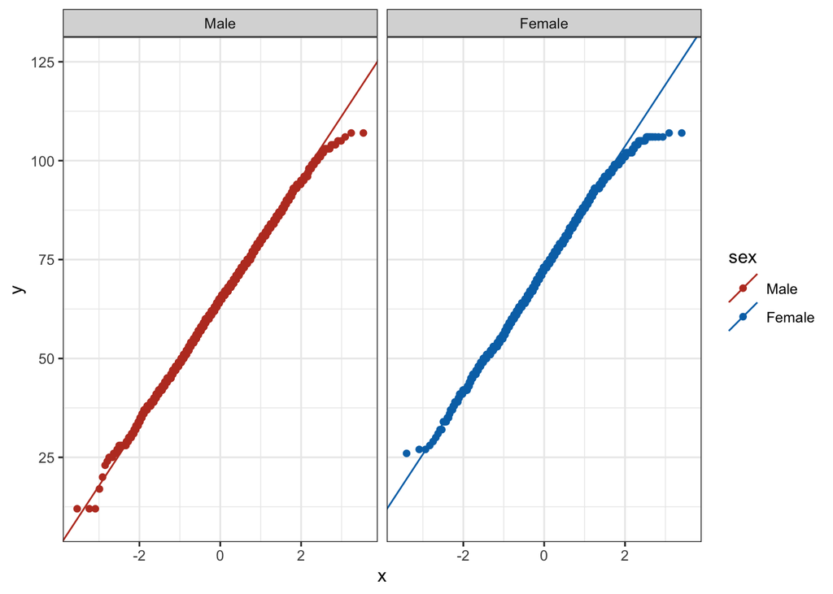

```r
data_cov_02 |>
  mutate(sex = factor(sex, levels = c(1,2), labels = c("Male", "Female"))) |>
  ggplot(aes(sample = age, group = sex, color = sex, fill = sex)) +
  geom_qq() +
  geom_qq_line() +
  facet_wrap(~sex) +
  ggsci::scale_fill_nejm() +
  ggsci::scale_color_nejm() +
  theme_bw()
```

**Note**

**Explanation**

- `mutate(sex = factor(...))`

  Converts the numeric sex variable (1/2) into a labeled factor with levels “Male” and “Female” — making the plot more interpretable.
- `ggplot(aes(...))`

  Initialises a ggplot object using age as the variable to be plotted in a Q-Q plot.
  - sample = age: Specifies the variable to be compared against a theoretical normal distribution.
  - group = sex: Ensures separate Q-Q plots are generated for each sex group.
  - color and fill: Assign colors based on sex.
- `geom_qq()`

  Adds a Q-Q plot layer — this visualizes how the distribution of age compares to a normal distribution.
- `geom_qq_line()`

  Adds a reference line to the Q-Q plot — if the data follows a normal distribution, points should lie close to this line.
- `facet_wrap(~sex)`

  Creates separate plots for “Male” and “Female” — allowing for side-by-side comparison of age distributions.
- `ggsci::scale_fill_nejm()` and `ggsci::scale_color_nejm()`

  Applies a color palette inspired by the *New England Journal of Medicine*.

  Note, here we call the functions directly from the `ggsci` package. We could also load the package under “Load packages”. That will largely depend on how frequently we will use it, and whether it conflicts with other packages. But, we should add it as a workflow-dependency package in our `DESCRIPTION` file.

  ```r
  usethis::use_package("ggsci")
  ```

- `theme_bw()`

  Applies a minimal black-and-white theme — removes background shading and grid clutter for a cleaner appearance. There are tons of themes you can use. Moreover, using the `theme()` function, you can customise your layout extensively.

#### 7.5.1.3 Histogram

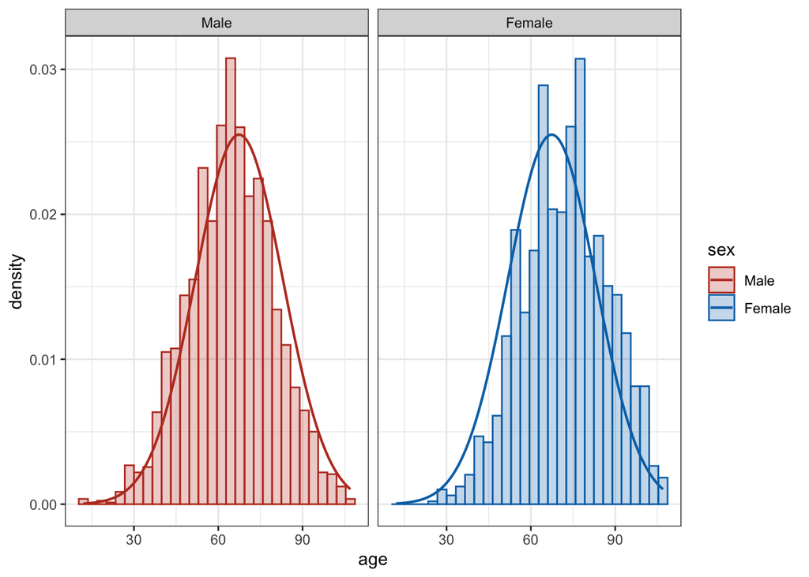

```r
data_cov_02 |>
  mutate(sex = factor(sex, levels = c(1, 2), labels = c("Male", "Female"))) |>
  ggplot(aes(x = age, group = sex, color = sex, fill = sex)) +
  geom_histogram(aes(y = after_stat(density)), alpha = .25) +
  stat_function(fun=dnorm, args = list(mean = mean(data_cov_02$age), sd = sd(data_cov_02$age)), linewidth = .75) +
  facet_wrap(~ sex) +
  ggsci::scale_fill_nejm() +
  ggsci::scale_color_nejm() +
  theme_bw()
```

**Note**

**Explanation**

- `mutate(sex = factor(...))`

  Converts the numeric sex variable (1 = Male, 2 = Female) into a labeled factor for clearer plotting and legend labels.
- `ggplot(aes(...))`
- Initializes the plot using age as the x-axis variable.
  - group = sex: Ensures separate density curves per sex.
  - color and fill: Assign colors based on sex for visual distinction.
- `geom_histogram(aes(y = ..density..), alpha = .25)`  
  Plots a histogram of the age variable, scaled to show density rather than raw counts.
  - alpha = .25: Makes the bars semi-transparent so overlapping areas are visible.
- `stat_function(fun = dnorm, ...)`

  Adds a normal distribution curve over the histogram using the overall mean and standard deviation of age.
  - This helps visually compare the actual age distribution to a theoretical normal distribution.
- `facet_wrap(~ sex)`  
  Creates separate panels for “Male” and “Female” — allowing side-by-side comparison of age distributions.

`ggsci::scale_fill_nejm()` and `ggsci::scale_color_nejm()`

Applies a color palette inspired by the *New England Journal of Medicine*.

Note, here we call the functions directly from the `ggsci` package. We could also load the package under “Load packages”. That will largely depend on how frequently we will use it, and whether it conflicts with other packages. But, we should add it as a workflow-dependency package in our `DESCRIPTION` file.

- `theme_bw()`

  Applies a minimal black-and-white theme — removes background shading and grid clutter for a cleaner appearance. There are tons of themes you can use. Moreover, using the `theme()` function, you can customise your layout intensively.

## 7.6 Comorbidities

The `diag_data` contains the following diseases and codes.

Comorbidities and ICD-10 codes

| Comorbidity | ICD-10 code |
| --- | --- |
| Myocardial infarction | DI21 |
| Hypertension | DI10, DI11, DI12, DI13, DI14, DI15 |
| Hypercholesterolaemia | DE78 |
| Diabetes | DE10, DE11, DE12, DE13, DE14 |
| Heart failure | DI50 |
| Random | DX01, DX02, DX03, DX04, DX05, DX06, DX07, DX08, DX09 |

There are several different ways to identify comorbidities. Here, we will go over a couple.

We set some assumptions.

1. We do not include information on diagnoses recorded during index admission
2. We include diagnoses recorded within 10 years from the index date (*i.e.*, 10 years lookback)
3. We include diagnoses from both inpatient and outpatient hospital contacts
4. We include diagnoses recorded as either a primary and a secondary diagnosis.
5. We apply the same assumptions for all comorbidities.

### 7.6.1 Baseline, identify, add

One approach is to

#### 7.6.1.1 Step 1.

1. Define a baseline study pop set

```r
data_baseline_mi <- data_pop_mi |>
  select(id, index_date)
```

#### 7.6.1.2 Step 2.

1. Add `diag_data` to our new `data_baseline_mi`
2. Keep only diagnoses recorded before the index date and within the lookback period
3. Then we have our basic dataset with all preadmission hospital contacts

```r
lookback_years <- 10

data_cov_diag <- data_baseline_mi |>
  left_join(diag_data, by = "id") |>
  mutate(
    diff = as.numeric(difftime(adm_date,index_date, units = "days")) # can also be switched, then adjust definition of lookback
  ) |>
  filter(
    diff < 0,
    diff > (-365.25*lookback_years)
  )

data_cov_diag
```

```
# A tibble: 7,917 × 8
   id    index_date contact_type adm_date   dis_date   diag_a diag_b  diff
   <fct> <date>     <fct>        <date>     <date>     <chr>  <chr>  <dbl>
 1 949   2021-11-03 2            2015-07-02 2015-07-02 DE78   DE78   -2316
 2 949   2021-11-03 1            2017-06-07 2017-06-08 DI50   DI50   -1610
 3 949   2021-11-03 2            2020-06-26 2020-06-26 DE78   DE78    -495
 4 949   2021-11-03 1            2021-01-07 2021-01-11 DI50   DI50    -300
 5 949   2021-11-03 1            2021-03-14 2021-03-20 DI50   DI50    -234
 6 949   2021-11-03 2            2021-06-25 2021-06-25 DE78   DE78    -131
 7 982   2015-05-22 2            2010-07-27 2010-07-27 DE78   DE78   -1760
 8 982   2015-05-22 2            2011-01-18 2011-01-18 DE78   DE78   -1585
 9 982   2015-05-22 2            2012-12-26 2012-12-26 DE78   DE78    -877
10 1123  2015-07-25 2            2011-01-13 2011-01-13 DE78   DE78   -1654
# ℹ 7,907 more rows
```

Now, we could do some checks. This is easily done with some base R manouvers.

```r
# Is the largest difference between index date and covariate admission lower than or equal to the lookback period?
min(data_cov_diag[["diff"]])
```

```
[1] -3649
```

```r
# Is the lowest difference between index date and covariate admission lower than 0 days?
max(data_cov_diag[["diff"]])
```

```
[1] -1
```

#### 7.6.1.3 Step 3.

Identify a given covariate. Let’s begin with hypertension.

Note: This approach keeps only those with a given covariate within the lookback period.

```r
hypertension_code <- c("DI1[0-5]")

cov_hypertension <- data_cov_diag |>
  mutate(
    hypertension =
      case_when(
        str_detect(diag_a, hypertension_code) | str_detect(diag_b, hypertension_code) ~ 1,
        .default = 0
      )) |>
  filter(hypertension == 1) |>
  select(id, hypertension) |>
  distinct()
```

#### 7.6.1.4 Step 4.

We therefore need to add the covariate to the baseline and replace `NA` with `0.`

```r
data_baseline_mi <-
  data_baseline_mi |>
  left_join(cov_hypertension, by = "id") |>
  mutate(hypertension = replace_na(hypertension, 0))
```

#### 7.6.1.5 Step 5.

Repeat the same procedure for hypercholesterolaemia

```r
hyperchol_code <- "DE78"

cov_hyperchol <- data_cov_diag |>
  mutate(
    hyperchol =
      case_when(
        str_detect(diag_a, hyperchol_code) | str_detect(diag_b, hyperchol_code) ~ 1,
        .default = 0
      )) |>
  filter(hyperchol == 1) |>
  select(id, hyperchol) |>
  distinct()

data_baseline_mi <-
  data_baseline_mi |>
  left_join(cov_hyperchol, by = "id") |>
  mutate(hyperchol = replace_na(hyperchol, 0))

data_baseline_mi
```

```
# A tibble: 4,000 × 4
   id    index_date hypertension hyperchol
   <fct> <date>            <dbl>     <dbl>
 1 212   2014-07-18            0         0
 2 483   2017-12-10            0         0
 3 731   2023-07-27            0         0
 4 949   2021-11-03            0         1
 5 981   2020-08-05            0         0
 6 982   2015-05-22            0         1
 7 1123  2015-07-25            0         1
 8 2166  2016-09-30            0         1
 9 2469  2023-08-26            0         0
10 2870  2010-09-03            0         0
# ℹ 3,990 more rows
```

#### 7.6.1.6 Step 6.

Keep on repeating..

While this approach does work, it gets slightly redundant, and we are repeating ourselves a lot!

Let’s explore a different approach using functions and loops.

We begin by tidying our environment.

```r
rm(data_baseline_mi, data_cov_diag, cov_hyperchol, cov_hypertension, hypertension_code, hyperchol_code)
```

### 7.6.2 Function based

As the number of comorbidities grows, repeating the same code for each one becomes inefficient and hard to maintain. A more efficient and slightly advanced approach is to:

- Create a **baseline dataset** with one row per patient containing only `id` and `index_date`
- Add preadmission hospital contacts to get a dataset like our `data_cov_diag`
- Define a **comorbidity table** with comorbidity names and ICD-10 patterns
- Write a **function** that identifies patients who have a history of a given comorbidity
- Use `for loop` to apply the function over several comorbidities and combine the results into a single dataset

This method is scalable, readable, and easy to adapt to new comorbidities.

#### 7.6.2.1 Step 1.

Make a baseline dataset onto which we will add covariate indicators

```r
data_covariate_mi <- data_pop_mi |>
  select(id, index_date)


lookback_years <- 10

data_cov_diag <- data_covariate_mi |>
  left_join(diag_data, by = "id") |>
  mutate(
    diff = as.numeric(difftime(adm_date,index_date, units = "days")) # can also be switched, then adjust definition of lookback
  ) |>
  filter(
    diff < 0,
    diff > (-365.25*lookback_years)
  )

data_cov_diag
```

```
# A tibble: 7,917 × 8
   id    index_date contact_type adm_date   dis_date   diag_a diag_b  diff
   <fct> <date>     <fct>        <date>     <date>     <chr>  <chr>  <dbl>
 1 949   2021-11-03 2            2015-07-02 2015-07-02 DE78   DE78   -2316
 2 949   2021-11-03 1            2017-06-07 2017-06-08 DI50   DI50   -1610
 3 949   2021-11-03 2            2020-06-26 2020-06-26 DE78   DE78    -495
 4 949   2021-11-03 1            2021-01-07 2021-01-11 DI50   DI50    -300
 5 949   2021-11-03 1            2021-03-14 2021-03-20 DI50   DI50    -234
 6 949   2021-11-03 2            2021-06-25 2021-06-25 DE78   DE78    -131
 7 982   2015-05-22 2            2010-07-27 2010-07-27 DE78   DE78   -1760
 8 982   2015-05-22 2            2011-01-18 2011-01-18 DE78   DE78   -1585
 9 982   2015-05-22 2            2012-12-26 2012-12-26 DE78   DE78    -877
10 1123  2015-07-25 2            2011-01-13 2011-01-13 DE78   DE78   -1654
# ℹ 7,907 more rows
```

```r
min(data_cov_diag[["diff"]])
```

```
[1] -3649
```

```r
max(data_cov_diag[["diff"]])
```

```
[1] -1
```

#### 7.6.2.2 Step 2.

Make a list of diseases and their corresponding codes

Then we list the diseases of interest and their ICD-10 codes in a vector. This can also be an Excel-file you prepare and load into `R`.

```r
comorbidity_definitions <-
  tibble::tibble(
  name = c("hypertension", "hypercholesterolaemia", "diabetes", "heart_failure"),
  pattern = c("DI1[0-5]", "DE78", "DE1[0-4]", "DI50")
)

comorbidity_definitions
```

```
# A tibble: 4 × 2
  name                  pattern
  <chr>                 <chr>
1 hypertension          DI1[0-5]
2 hypercholesterolaemia DE78
3 diabetes              DE1[0-4]
4 heart_failure         DI50
```

#### 7.6.2.3 Step 3.

Make a function

1. We first `message` the name of the covariate. This help us keeping track on the progress.
2. We then set the code pattern to be used. We simply extract the code related to the covariate as defined in our `comorbidity_definions` data.
3. We then identify whether a given contact has a record with the disease of interest.
4. We then only keep relevant contacts and keep id and the covariate indicator.
5. Finally, we return the specific dataset containing the covariate indicator.

```r
identify_comorbidity <- function(data, disease_name) {

  disease_name_sym <- rlang::sym(disease_name)

  # step 01
  print(disease_name)

  # step 02
  code <- comorbidity_definitions[["pattern"]][comorbidity_definitions[["name"]] == disease_name]

  cov_data <- data |>

    # step 03
    dplyr::mutate(
      !!disease_name_sym := dplyr::case_when(
        str_detect(diag_a, code) | str_detect(diag_b, code) ~ 1,
        .default = 0
      )
    ) |>

    # step 04
    dplyr::filter(!!disease_name_sym == 1) |>
    dplyr::select(id, !!disease_name_sym) |>
    dplyr::distinct()

  # step 05
  return(cov_data)

}
```

#### 7.6.2.4 Step 4.

Apply the function using a `for loop`

Essentially, the `for loop` runs the function above for each disease name in our `comorbidity_definition` dataset. It then adds the covariate indicator to `data_covariate_mi`.

```r
for (disease_name in comorbidity_definitions[["name"]]) {

  output <- identify_comorbidity(
    data = data_cov_diag,
    disease_name = disease_name
    )

  data_covariate_mi <- dplyr::left_join(data_covariate_mi, output, by = "id") |>
    dplyr::distinct()

}
```

```
[1] "hypertension"
[1] "hypercholesterolaemia"
[1] "diabetes"
[1] "heart_failure"
```

#### 7.6.2.5 Step 5.

Combine with age and sex

1. Combine information on age and sex with the covariate data to get a full baseline dataset.
2. Then, we replace `NA` with `0` for the covariate dummy variables. We could write out each covariate name, but we might as well be lazy and get some help from the `comorbidity_definitons` dataset :-)

```r
data_baseline_mi <-
  data_cov_02 |>
  left_join(data_covariate_mi, by = c("id", "index_date"))

covariates <- paste0(comorbidity_definitions$name)

data_baseline_mi <- data_baseline_mi |>
  mutate(
    across(c(
           covariates
           ),
           ~ replace_na(.x, 0)
  )
  )

data_baseline_mi
```

```
# A tibble: 4,000 × 10
   id    index_date   los birth_date sex     age hypertension
   <fct> <date>     <dbl> <date>     <fct> <dbl>        <dbl>
 1 212   2014-07-18     4 1941-01-01 1        73            0
 2 483   2017-12-10     9 1918-01-01 2        99            0
 3 731   2023-07-27     7 1931-01-01 2        92            0
 4 949   2021-11-03     7 1954-01-01 1        67            0
 5 981   2020-08-05    13 1945-01-01 2        75            0
 6 982   2015-05-22     6 1945-01-01 2        70            0
 7 1123  2015-07-25     6 1955-01-01 1        60            0
 8 2166  2016-09-30     7 1962-01-01 1        54            0
 9 2469  2023-08-26     5 1920-01-02 2       103            0
10 2870  2010-09-03    14 1939-01-01 1        71            0
# ℹ 3,990 more rows
# ℹ 3 more variables: hypercholesterolaemia <dbl>, diabetes <dbl>,
#   heart_failure <dbl>
```

## 7.7 Save

```r
saveRDS(data_baseline_mi, here::here("data/data_baseline_mi.rds"))
```

## 7.8 Clear environment

```
          used  (Mb) gc trigger  (Mb) limit (Mb) max used  (Mb)
Ncells 2624299 140.2    4697498 250.9         NA  4697498 250.9
Vcells 6408561  48.9   40875687 311.9      16384 50499387 385.3
```